# Scatterplot version of heat maps

Joshua P. French

2021-03-15

## Introduction

The **autoimage** package makes it easy to plot a sequence of images with corresponding color scales, i.e., a sequence of heat maps, with straightforward, native options for projection of geographical coordinates. The package makes it simple to add lines, points, and other features to the images, even when the coordinates are projected.

The package also makes it easy to create a “heated scatterplot”, which is similar to a heat map in that color is used to distinguish smaller and larger values of a variable observed over a two-dimensional domain, but is different from a heat map in that the observed data locations are not gridded. Instead of interpolating the data locations onto a grid, the colors are displayed through a typical two-dimensional scatterplot.

The `autopoints` function is the main function for creating a sequence of heated scatterplots; it relies on the helper function `heat_ppoints`, which can be used in more complex scenarios. We provide the examples below with brief explanation.

## `autopoints` Examples

We provide examples using the non-gridded Aluminum and Cadmium measurements for the state of Colorado, which are available in the **gear** package.

Here is a basic heated scatterplot for Aluminum with custom x and y axis labels.

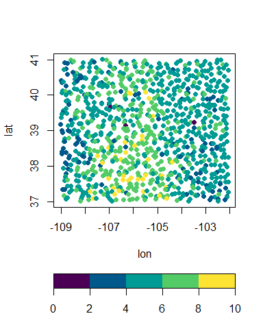

```r
library(autoimage)
data(co, package = "gear")
autopoints(co$longitude, co$latitude, co$Al,
       xlab = "lon", ylab = "lat")
```

In the sets of examples, we display heated scatterplots for Aluminum and Cadmium while allowing them to have different z limits and z limit breaks for the color scale. We illustrate a few different combinations using defaults and by specifying `zlim` and `breaks` as lists.

The following example uses the `autopoints` default options, which automatically determines the color scale break labels using the the **base** `pretty` function.

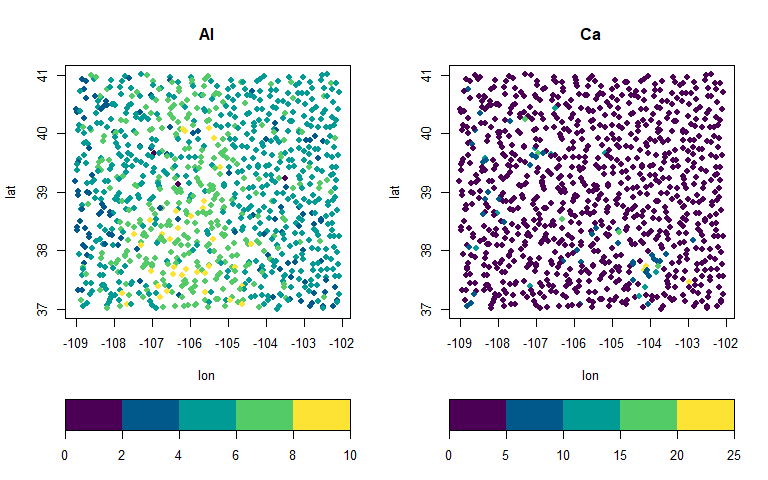

```r
autopoints(co$longitude, co$latitude, co[, c("Al", "Ca")],
       xlab = "lon", ylab = "lat", common.legend = FALSE,
       main = c("Al", "Ca"))
```

In the next example, we manually specify the z limits, after using the `summary` function to determine appropriate limis.

```r
summary(co[, c("Al", "Ca")])
```

```
##        Al              Ca
##  Min.   :1.120   Min.   : 0.110
##  1st Qu.:4.660   1st Qu.: 0.710
##  Median :5.540   Median : 1.230
##  Mean   :5.531   Mean   : 1.963
##  3rd Qu.:6.353   3rd Qu.: 2.375
##  Max.   :9.980   Max.   :21.900
```

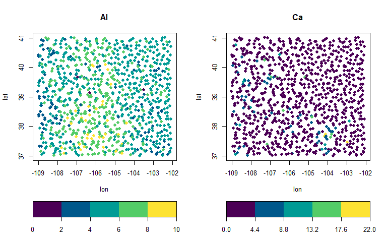

```r
autopoints(co$longitude, co$latitude, co[, c("Al", "Ca")],
       xlab = "lon", ylab = "lat", common.legend = FALSE,
       main = c("Al", "Ca"), zlim = list(c(0, 10), c(0, 22)))
```

Finally, we manually specify the breaks of each variable, which allows for different numbers of colors for each plot.

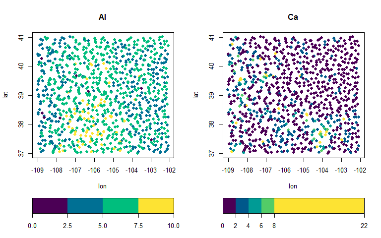

```r
autopoints(co$longitude, co$latitude, co[, c("Al", "Ca")],
       xlab = "lon", ylab = "lat", common.legend = FALSE,
       main = c("Al", "Ca"),
       breaks = list(seq(0, 10, by = 2.5),
                     c(0, 2, 4, 6, 8, 22)))
```

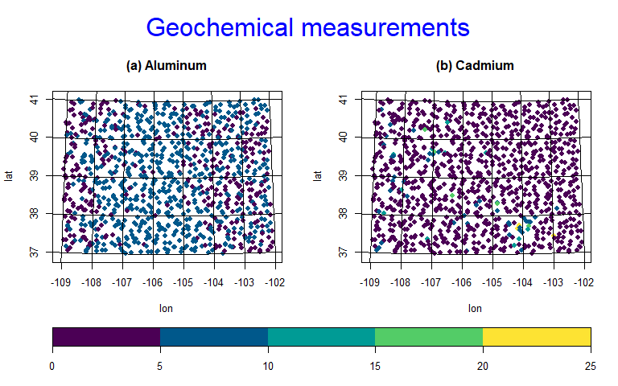

```r
autopoints(co$longitude, co$latitude, co[, c("Al", "Ca")],
       xlab = "lon", ylab = "lat",
       proj = "bonne", parameters = 40,
       paxes.args = list(col = "lightgrey"),
       axis.args = list(yat = 35:43,
                        xat = -(110:101)),
       main = c("(a) Aluminum", "(b) Cadmium"),
       outer.title = "Geochemical measurements",
       mtext.args = list(col = "blue", cex = 2))
```

We can add selected borders via the `map` arguments (which makes use of the the `maps::map` function. We can also add borders/lines via the lines arguments. We demnstrate using USA county maps (`map = "county"`) and Colorado state borders (`lines = copoly`) where `copoly` is a polygon list available in the **autoimage** package. The lines can be customized through the `lines.args` argument list.

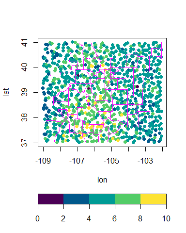

```r
autopoints(co$longitude, co$latitude, co$Al,
       xlab = "lon", ylab = "lat", map = "county",
       lines.args = list(col = "magenta"))
```

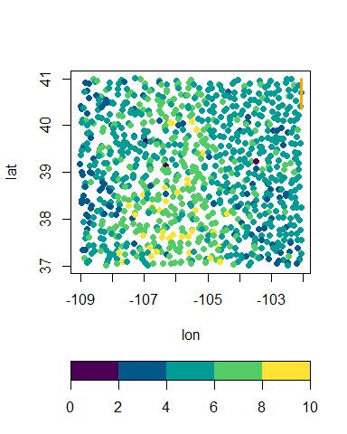

```r
data(copoly)
autopoints(co$longitude, co$latitude, co$Al,
       xlab = "lon", ylab = "lat", lines = copoly,
       lines.args = list(col = "orange", lwd = 3))
```

Naturally, one may wish to change the color palette or the breaks associated with the colors. This can be done via the `col` and `breaks` arguments. `breaks` must be a sequential vector with length one element longer than `col`. We also move the legend scale to the right side.

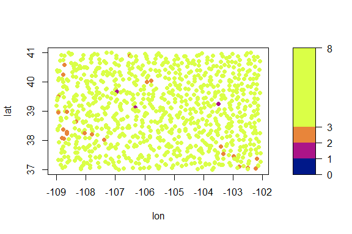

```r
autopoints(co$longitude, co$latitude, co$Al, legend = "v",
           xlab = "lon", ylab = "lat",
           col = colorspace::sequential_hcl(n = 4, palette = "Plasma"),
           breaks = c(0, 1, 2, 3, 8))
```

We add the locations and names of two Colorado cities to the Colorado geochemical data using the `points` and `text` arguments. The appearance of these can be customized through the `points.args` and `text.args` argument lists, respectively.

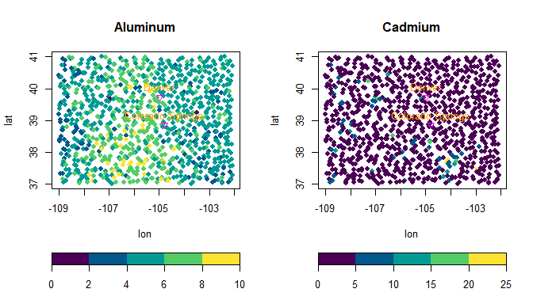

```r
citypoints = list(x = c(-104.98, -104.80), y = c(39.74, 38.85),
                  labels = c("Denver", "Colorado Springs"))
autopoints(co$lon, co$lat, co[,c("Al", "Ca")], common.legend = FALSE,
           main = c("Aluminum", "Cadmium"),
           points = citypoints,
           points.args = list(pch = 6, col = "magenta"),
           text = citypoints,
           text.args = list(pos = 3, col = "orange"),
           xlab = "lon", ylab = "lat")
```

## Richer plots using `autolayout` and `autolegend`

Suppose we want to add custom features to a sequences of images and heated scatterplots, with each plots receiving different features. One can create a richer sequence of images using the `autolayout` and `autolegend` functions.

```r
# load world map
data(worldMapEnv, package = "maps")
# extract hawaii and alaskan borders
hiak <- maps::map("world", c("USA:Hawaii", "USA:Alaska"),
                  plot = FALSE)
# load us city information
data(us.cities, package = "maps")
# extract colorado cities from us.cities
codf <- us.cities[us.cities$country.etc == "CO", ]
# select smaller subset of colorado cities
# extract capitals from us.cities
capdf <- us.cities[us.cities$capital == 2,]
```

Having obtained the relevant information, we setup a 1 $\times$ 2 matrix of images with individual horizontal legends and an area for a common title. We create an image plot of NARCCAP data using the mercator projection and including grey state borders. The borders of Hawaii and Alaska are added using the `plines` function. The state capitals are added to the image using the `ppoints` function. The first image is then titled using the `title` function. The legend is then added using the `autolegend` function. Next, a heated scatterplots of the Colorado Aluminum measurements is created using the `heat_ppoints` function. The coordinates are projected using the Bonne projection, the color scheme is customized, grey county borders are added to the plot, but the grid lines are removed. The `ppoints` function is then used to add locations for several Colorado cities to the image. The `ptext` function is then used to add the names of these cities to the image. The second heated scatterplot is then titled using the `title` function. The appropriate legend is then added using the `autolegend` function. Lastly, a common title is added using the `mtext` function.

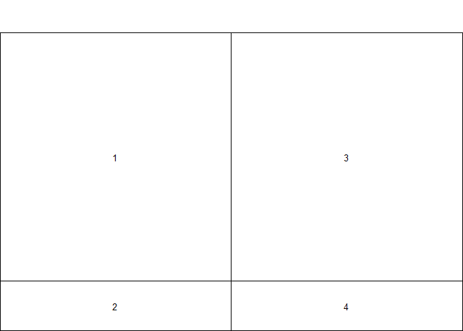

```r
# setup plotting area
autolayout(c(1, 2), legend = "h", common.legend = FALSE, outer = TRUE)
```

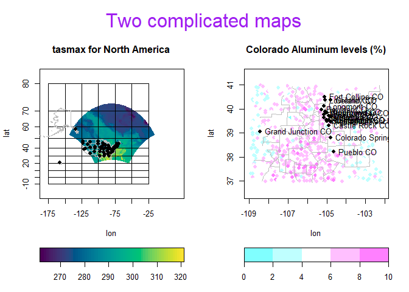

```r
# create image of NARCCAP data.
# xlim is chosen so to include alaska and hawaii
# add grey state borders
# extend graticules (longitude/latitude grid lines)
pimage(lon, lat, tasmax[,,1], legend = "none",
       proj = "mercator", map = "state",
       xlim = c(-180, 20),
       axis.args = list(xat = seq(-175, -25, by = 25),
                        yat = seq(-10, 80, len = 10)),
       lines.args = list(col = "grey"))
# add hawaii and alaskan borders
plines(hiak, proj = "mercator", col = "grey")
# add state captials to image
ppoints(capdf$lon, capdf$lat, proj = "mercator", pch = 16)
# title image
title("tasmax for North America")
# add legend for plot
autolegend()
# load colorado geochemical data
data(co, package = "gear")
# create image for colorado aluminum measurements
# use bonne projection
# customize legend colors
# add grey county borders
# exclude longitude/latitude
heat_ppoints(co$lon, co$lat, co$Al, map = "county", legend = "none",
       proj = "bonne", parameters = 39,
       paxes.args = list(grid = FALSE),
       col = cm.colors(5),
       lines.args = list(col = "grey"),
       xlab = "lon", ylab = "lat")
# add colorado city points to image
ppoints(codf$lon, codf$lat, pch = 16, proj = "bonne")
# add names of colorado cities to image
ptext(codf$lon, codf$lat, labels = codf$name, proj = "bonne", pos = 4)
# title plot
title("Colorado Aluminum levels (%)")
# add legend to current image
autolegend()
# add common title for plots
mtext("Two complicated maps", col = "purple", outer = TRUE, cex = 2)
```